# Part 2 - Where to enrich? (what are study areas?)

# Table of Contents

## Enriching Study Areas

GeoEnrichment uses the concept of a study area to define the location of the point or area that you want to enrich with additional information or create reports about. The accepted forms of study areas are:

1. Street address locations
   - a. Single line input
   - b. Multiple field input
2. Point, line and polygon geometries
3. Buffered study areas
4. Named statistical areas

Before we look at the exmaples of study areas, let's understand the concept of Data collections and analysis variables. We will look at Data collections in detail in a later section.

### Data collections and analysis variables

GeoEnrichment uses the concept of a data collection to define the data attributes (analysis variables) returned by the enrichment service. A data collection is a preassembled list of attributes that will be used to enrich the input features. Collection attributes can describe various types of information, such as demographic characteristics and geographic context of the locations or areas submitted as input features. We will introduce the concept of data collections here and look at the details in the next guide.

The `Country` class can be used to discover the data collections, sub-geographies and available reports for a country. When working with a particular country, you will find it convenient to get a reference to it using the Country.get() method.

The `data_collections` property of a `Country` object lists a combination of available data collections and analysis variables for each data collection as a [Pandas](https://pandas.pydata.org/) dataframe.

Once we know the data collection we would like to use, we can look at all the unique `analysisVariable` available in that data collection.

```python
# Import Libraries
from arcgis.gis import GIS
from arcgis.geoenrichment import Country, enrich, BufferStudyArea
```

```python
# Create a GIS Connection
gis = GIS(profile='your_online_profile')
```

```python
# Get US as a country
usa = Country.get('US')
type(usa)
```

```
arcgis.geoenrichment.enrichment.Country
```

```python
df = usa.data_collections

# print a few rows of the DataFrame
df.head()
```

| dataCollectionID | analysisVariable | alias | fieldCategory | vintage |
| --- | --- | --- | --- | --- |
| 1yearincrements | 1yearincrements.AGE0_CY | 2020 Population Age <1 | 2020 Age: 1 Year Increments (Esri) | 2020 |
| 1yearincrements | 1yearincrements.AGE1_CY | 2020 Population Age 1 | 2020 Age: 1 Year Increments (Esri) | 2020 |
| 1yearincrements | 1yearincrements.AGE2_CY | 2020 Population Age 2 | 2020 Age: 1 Year Increments (Esri) | 2020 |
| 1yearincrements | 1yearincrements.AGE3_CY | 2020 Population Age 3 | 2020 Age: 1 Year Increments (Esri) | 2020 |
| 1yearincrements | 1yearincrements.AGE4_CY | 2020 Population Age 4 | 2020 Age: 1 Year Increments (Esri) | 2020 |

```python
# call the shape property to get the total number of rows and columns
df.shape
```

```
(17608, 4)
```

Each data collection can have multiple analysis variables as seen in the table above. Every such analysis variable has a unique ID, found in the `analysisVariable` column. When calling the `enrich()` method, these analysis variables can be passed in the `data_collections` and `analysis_variables` parameters.

You can filter the `data_collections` and query the collections `analysis_variables` using Pandas expressions.

```python
# get all the unique data collections available for the current country
df.index.unique()
```

```
Index(['1yearincrements', '5yearincrements', 'ACS_Housing_Summary_rep',
       'ACS_Population_Summary_rep', 'Age', 'AgeDependency',
       'Age_50_Profile_rep', 'Age_by_Sex_Profile_rep',
       'Age_by_Sex_by_Race_Profile_rep', 'AtRisk',
       ...
       'transportation', 'travelMPI', 'unitsinstructure',
       'urbanizationgroupsNEW', 'vacant', 'vehiclesavailable', 'veterans',
       'women', 'yearbuilt', 'yearmovedin'],
      dtype='object', name='dataCollectionID', length=150)
```

The snippet below shows how you can query the `Age` data collection and get all the unique `analysisVariable`s under that collection.

```python
df.loc['Age']['analysisVariable'].unique()
```

```
array(['Age.MALE0', 'Age.MALE5', 'Age.MALE10', 'Age.MALE15', 'Age.MALE20',
       'Age.MALE25', 'Age.MALE30', 'Age.MALE35', 'Age.MALE40',
       'Age.MALE45', 'Age.MALE50', 'Age.MALE55', 'Age.MALE60',
       'Age.MALE65', 'Age.MALE70', 'Age.MALE75', 'Age.MALE80',
       'Age.MALE85', 'Age.FEM0', 'Age.FEM5', 'Age.FEM10', 'Age.FEM15',
       'Age.FEM20', 'Age.FEM25', 'Age.FEM30', 'Age.FEM35', 'Age.FEM40',
       'Age.FEM45', 'Age.FEM50', 'Age.FEM55', 'Age.FEM60', 'Age.FEM65',
       'Age.FEM70', 'Age.FEM75', 'Age.FEM80', 'Age.FEM85'], dtype=object)
```

```python
# View a sample of the `Age` data collection
df.loc['Age'].head()
```

| dataCollectionID | analysisVariable | alias | fieldCategory | vintage |
| --- | --- | --- | --- | --- |
| Age | Age.MALE0 | 2020 Males Age 0-4 | 2020 Age: 5 Year Increments (Esri) | 2020 |
| Age | Age.MALE5 | 2020 Males Age 5-9 | 2020 Age: 5 Year Increments (Esri) | 2020 |
| Age | Age.MALE10 | 2020 Males Age 10-14 | 2020 Age: 5 Year Increments (Esri) | 2020 |
| Age | Age.MALE15 | 2020 Males Age 15-19 | 2020 Age: 5 Year Increments (Esri) | 2020 |
| Age | Age.MALE20 | 2020 Males Age 20-24 | 2020 Age: 5 Year Increments (Esri) | 2020 |

Now, let's look at some examples of enriching each of the study areas.

### Enriching street address

Street address locations can be passed as strings of input street addresses, points of interest or place names. A street address can be passed as a single line or as a multiple field input. If a point (e.g. a street address) is used as a study area, the service will create a 1 mile ring buffer around the point to collect and append enrichment data.

The example below uses a `street address` as a study area for enrichment using `Age` data collection.

#### Single line address

```python
# Enriching single address as single line imput
single_address = enrich(study_areas=["380 New York St Redlands CA 92373"],
                       data_collections=['Age'])
```

```python
single_address
```

|  | ID | OBJECTID | sourceCountry | X | Y | areaType | bufferUnits | bufferUnitsAlias | bufferRadii | aggregationMethod | ... | FEM45 | FEM50 | FEM55 | FEM60 | FEM65 | FEM70 | FEM75 | FEM80 | FEM85 | SHAPE |
| --- | --- | --- | --- | --- | --- | --- | --- | --- | --- | --- | --- | --- | --- | --- | --- | --- | --- | --- | --- | --- | --- |
| 0 | 0 | 1 | US | -117.194872 | 34.057237 | RingBuffer | esriMiles | Miles | 1 | BlockApportionment:US.BlockGroups | ... | 376 | 398 | 374 | 340 | 310 | 262 | 153 | 98 | 129 | {"rings": [[[-117.19487199429183, 34.071745616... |

1 rows × 50 columns

##### Visualize results on a map

The returned spatial dataframe can be visualized on a map as shown below:

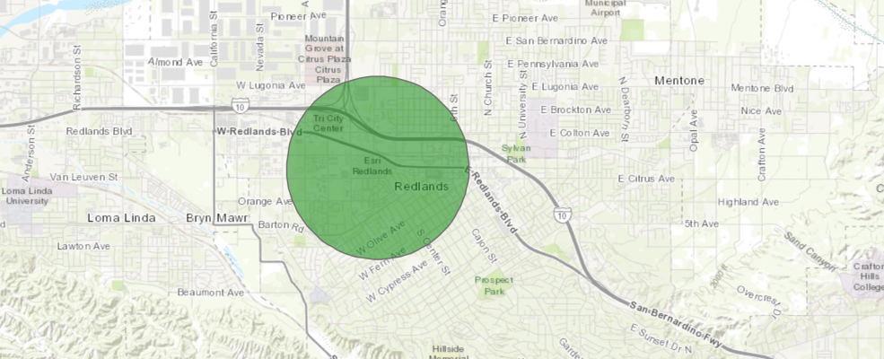

```python
# Plot on a map
address_map = gis.map('Redlands, CA',13)
address_map
```

A buffer of 1 mile is created by default, as seen on this map, for any address.

```python
single_address.spatial.plot(address_map)
```

```
True
```

**Multiple addresses as single line input**

```python
# Enriching multiple addresses as single line input
enrich(study_areas=[{"address":{"text":"12 Concorde Place Toronto ON M3C 3R8","sourceCountry":"Canada"}},
                    {"address":{"text":"380 New York St Redlands CA 92373","sourceCountry":"US"}}],
       data_collections=['Age'])
```

|  | ID | OBJECTID | sourceCountry | X | Y | areaType | bufferUnits | bufferUnitsAlias | bufferRadii | aggregationMethod | ... | ECYPFA4549 | ECYPFA5054 | ECYPFA5559 | ECYPFA6064 | ECYPFA6569 | ECYPFA7074 | ECYPFA7579 | ECYPFA8084 | ECYPFA85P | SHAPE |
| --- | --- | --- | --- | --- | --- | --- | --- | --- | --- | --- | --- | --- | --- | --- | --- | --- | --- | --- | --- | --- | --- |
| 0 | 0 | 1 | CA | -79.328740 | 43.729720 | RingBuffer | esriMiles | Miles | 1 | BlockApportionment:CAN.DA | ... | 1351.0 | 1264.0 | 1323.0 | 1138.0 | 1156.0 | 973.0 | 784.0 | 576.0 | 970.0 | {"rings": [[[-79.3287400246266, 43.74420464321... |
| 1 | 1 | 2 | US | -117.194872 | 34.057237 | RingBuffer | esriMiles | Miles | 1 | BlockApportionment:US.BlockGroups | ... | NaN | NaN | NaN | NaN | NaN | NaN | NaN | NaN | NaN | {"rings": [[[-117.19487199429183, 34.071745616... |

2 rows × 50 columns

#### Multiple field input

```python
enrich(study_areas=[{"address":{"Address":"380 New York Street",
                                "City":"Redlands", "Region":"CA", "Postal":92373}}],
       data_collections=['Age'])
```

|  | ID | OBJECTID | sourceCountry | X | Y | areaType | bufferUnits | bufferUnitsAlias | bufferRadii | aggregationMethod | ... | FEM45 | FEM50 | FEM55 | FEM60 | FEM65 | FEM70 | FEM75 | FEM80 | FEM85 | SHAPE |
| --- | --- | --- | --- | --- | --- | --- | --- | --- | --- | --- | --- | --- | --- | --- | --- | --- | --- | --- | --- | --- | --- |
| 0 | 0 | 1 | US | -117.194872 | 34.057237 | RingBuffer | esriMiles | Miles | 1 | BlockApportionment:US.BlockGroups | ... | 376 | 398 | 374 | 340 | 310 | 262 | 153 | 98 | 129 | {"rings": [[[-117.19487199429183, 34.071745616... |

1 rows × 50 columns

Enriching with various analysis variables for age such as `FEM45, FEM50, FEM65` etc.

```python
enrich(study_areas=["380 New York St Redlands CA 92373"],
       analysis_variables=["Age.FEM45","Age.FEM55","Age.FEM65"])
```

|  | ID | OBJECTID | sourceCountry | X | Y | areaType | bufferUnits | bufferUnitsAlias | bufferRadii | aggregationMethod | populationToPolygonSizeRating | apportionmentConfidence | HasData | FEM45 | FEM55 | FEM65 | SHAPE |
| --- | --- | --- | --- | --- | --- | --- | --- | --- | --- | --- | --- | --- | --- | --- | --- | --- | --- |
| 0 | 0 | 1 | US | -117.194872 | 34.057237 | RingBuffer | esriMiles | Miles | 1 | BlockApportionment:US.BlockGroups | 2.191 | 2.576 | 1 | 376 | 374 | 310 | {"rings": [[[-117.19487199429183, 34.071745616... |

### Enriching point, line and polygon geometries

Point geometries can be passed as x and y coordinates to `study_areas` parameter. When points are specified as study areas, the service will analyze map areas surrounding or associated with the input point locations. Unless otherwise specified, the service will analyze a one mile ring around a point. This is also true for a line. Locations can also be given as polygon geometries.

#### Single Point described as map coordinates

```python
from arcgis.geometry import Point
```

```python
pt = Point({"x" : -117.1956, "y" : 34.0572, "spatialReference" : {"wkid" : 4326}})
enrich(study_areas=[pt], data_collections=['Age'])
```

|  | ID | OBJECTID | sourceCountry | areaType | bufferUnits | bufferUnitsAlias | bufferRadii | aggregationMethod | populationToPolygonSizeRating | apportionmentConfidence | ... | FEM45 | FEM50 | FEM55 | FEM60 | FEM65 | FEM70 | FEM75 | FEM80 | FEM85 | SHAPE |
| --- | --- | --- | --- | --- | --- | --- | --- | --- | --- | --- | --- | --- | --- | --- | --- | --- | --- | --- | --- | --- | --- |
| 0 | 0 | 1 | US | RingBuffer | esriMiles | Miles | 1 | BlockApportionment:US.BlockGroups | 2.191 | 2.576 | ... | 364 | 388 | 361 | 329 | 300 | 253 | 147 | 92 | 122 | {"rings": [[[-117.19559999999998, 34.071708616... |

1 rows × 48 columns

#### Multiple points with attributes described as map coordinates

```python
pt1 = Point({"x" : -122.435, "y" : 37.785, "spatialReference" : {"wkid" : 4326}})
pt2 = Point({"x" : -122.433, "y" : 37.734, "spatialReference" : {"wkid" : 4326}})

enrich(study_areas=[pt1, pt2], data_collections=['Age'])
```

|  | ID | OBJECTID | sourceCountry | areaType | bufferUnits | bufferUnitsAlias | bufferRadii | aggregationMethod | populationToPolygonSizeRating | apportionmentConfidence | ... | FEM45 | FEM50 | FEM55 | FEM60 | FEM65 | FEM70 | FEM75 | FEM80 | FEM85 | SHAPE |
| --- | --- | --- | --- | --- | --- | --- | --- | --- | --- | --- | --- | --- | --- | --- | --- | --- | --- | --- | --- | --- | --- |
| 0 | 0 | 1 | US | RingBuffer | esriMiles | Miles | 1 | BlockApportionment:US.BlockGroups | 2.191 | 2.576 | ... | 2994 | 2581 | 2615 | 2773 | 2602 | 2394 | 1926 | 1564 | 2351 | {"rings": [[[-122.43499999999999, 37.799499596... |
| 1 | 1 | 2 | US | RingBuffer | esriMiles | Miles | 1 | BlockApportionment:US.BlockGroups | 2.191 | 2.576 | ... | 2444 | 2373 | 2378 | 2164 | 2004 | 1660 | 1097 | 798 | 1040 | {"rings": [[[-122.43299999999999, 37.748499722... |

2 rows × 48 columns

#### Line feature described as geometry

```python
from arcgis.geometry import Polyline
```

```python
line = Polyline({"paths":[[[-13048580,4036370],[-13046151,4036366]]],
                 "spatialReference":{"wkid":102100}})
enriched_line_df = enrich(study_areas=[line], data_collections=['Age'])
```

```python
enriched_line_df
```

|  | ID | OBJECTID | sourceCountry | areaType | bufferUnits | bufferUnitsAlias | bufferRadii | aggregationMethod | populationToPolygonSizeRating | apportionmentConfidence | ... | FEM45 | FEM50 | FEM55 | FEM60 | FEM65 | FEM70 | FEM75 | FEM80 | FEM85 | SHAPE |
| --- | --- | --- | --- | --- | --- | --- | --- | --- | --- | --- | --- | --- | --- | --- | --- | --- | --- | --- | --- | --- | --- |
| 0 | 0 | 1 | US | RingBuffer | esriMiles | Miles | 1 | BlockApportionment:US.BlockGroups | 2.191 | 2.576 | ... | 585 | 585 | 528 | 498 | 443 | 389 | 227 | 151 | 228 | {"rings": [[[-117.21736177272676, 34.070851408... |

1 rows × 48 columns

##### Visualize results on a map

The returned spatial dataframe can be visualized on a map as shown below:

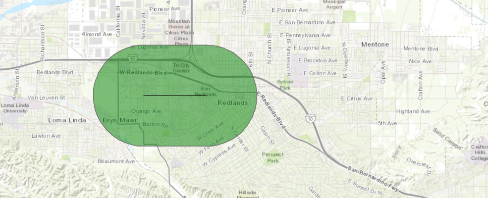

```python
# Plot on a map
line_map = gis.map('Redlands, CA',13)
line_map
```

We can clearly see the line and a 1 mile buffer around the line in this map

```python
# Draw line
line_map.draw(line)

# Plot enriched area around line
enriched_line_df.spatial.plot(line_map)
```

```
True
```

#### Map area described as polygons

```python
from arcgis.geometry import Polygon
```

```python
poly = Polygon({"rings":[[[-117.185412,34.063170],[-122.81,37.81],
                        [-117.200570,34.057196],[-117.185412,34.063170]]],
                        "spatialReference":{"wkid":4326}})

enrich(study_areas=[poly], data_collections=['Age'])
```

|  | ID | OBJECTID | sourceCountry | aggregationMethod | populationToPolygonSizeRating | apportionmentConfidence | HasData | MALE0 | MALE5 | MALE10 | ... | FEM45 | FEM50 | FEM55 | FEM60 | FEM65 | FEM70 | FEM75 | FEM80 | FEM85 | SHAPE |
| --- | --- | --- | --- | --- | --- | --- | --- | --- | --- | --- | --- | --- | --- | --- | --- | --- | --- | --- | --- | --- | --- |
| 0 | 0 | 1 | US | BlockApportionment:US.BlockGroups | 2.191 | 2.576 | 1 | 5532 | 5473 | 5286 | ... | 3865 | 3905 | 3896 | 3528 | 2710 | 1997 | 1303 | 844 | 943 | {"rings": [[[-117.20057, 34.057196], [-122.809... |

1 rows × 44 columns

### Enriching Buffered study areas

`BufferStudyArea` instances are used to change the ring buffer size or create drive-time service areas around points specified using one of the above methods. BufferStudyArea allows you to buffer point and street address study areas. They can be created using the following parameters:

```
    * area: the point geometry or street address (string) study area to be buffered
    * radii: list of distances by which to buffer the study area, eg. [1, 2, 3]
    * units: distance unit, eg. Miles, Kilometers, Minutes (when using drive times/travel_mode)
    * overlap: boolean, uses overlapping rings/network service areas when True, or non-overlapping disks when False
    * travel_mode: None or string, one of the supported travel modes when using network service areas
```

`BufferStudyArea` also allows you to define drive time service areas around points as well as other advanced service areas such as walking and trucking.

#### Buffering location using driving distance

The example below creates disks of radii 1, 3 and 5 Miles respectively from a street address and enriches these using the 'Age' data collection.

```python
buffered = BufferStudyArea(area='380 New York St Redlands CA 92373',
                           radii=[1,3,5], units='Miles', overlap=False)
drive_dist_df = enrich(study_areas=[buffered], data_collections=['Age'])
```

```python
drive_dist_df
```

|  | ID | OBJECTID | sourceCountry | X | Y | areaType | bufferUnits | bufferUnitsAlias | bufferRadii | aggregationMethod | ... | FEM45 | FEM50 | FEM55 | FEM60 | FEM65 | FEM70 | FEM75 | FEM80 | FEM85 | SHAPE |
| --- | --- | --- | --- | --- | --- | --- | --- | --- | --- | --- | --- | --- | --- | --- | --- | --- | --- | --- | --- | --- | --- |
| 0 | 0 | 1 | US | -117.194872 | 34.057237 | RingBufferBands | Miles | Miles | 1 | BlockApportionment:US.BlockGroups | ... | 376 | 398 | 374 | 340 | 310 | 262 | 153 | 98 | 129 | {"rings": [[[-117.19487199429183, 34.071745616... |
| 1 | 0 | 2 | US | -117.194872 | 34.057237 | RingBufferBands | Miles | Miles | 3 | BlockApportionment:US.BlockGroups | ... | 1935 | 1936 | 1999 | 2073 | 1789 | 1430 | 986 | 719 | 947 | {"rings": [[[-117.19487199429183, 34.100762745... |
| 2 | 0 | 3 | US | -117.194872 | 34.057237 | RingBufferBands | Miles | Miles | 5 | BlockApportionment:US.BlockGroups | ... | 2375 | 2493 | 2601 | 2478 | 2008 | 1500 | 1062 | 780 | 1018 | {"rings": [[[-117.19487199429183, 34.129779737... |

3 rows × 50 columns

##### Visualize results on a map

The returned spatial dataframe can be visualized on a map as shown below:

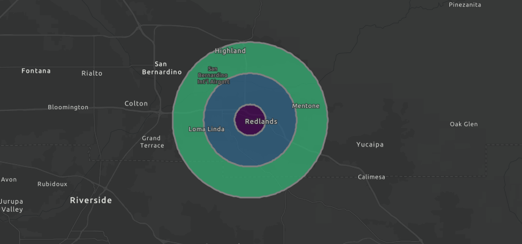

```python
# Plot on a map
buffer_map1 = gis.map('Redlands, CA')
buffer_map1.basemap = 'dark-gray-vector'
buffer_map1
```

```python
drive_dist_df.spatial.plot(map_widget=buffer_map1,
               renderer_type='c',  # for class breaks renderer
               method='esriClassifyNaturalBreaks',  # classification algorithm
               class_count=4,  # choose the number of classes
               col='bufferRadii',  # numeric column to classify
               cmap='viridis',  # color map to pick colors from for each class
               alpha=0.7  # specify opacity
               )
```

```
True
```

#### Buffering location using drive times

The example below creates 5 and 10 minute drive times from a street address and enriches these using the 'Age' data collection.

```python
buffered = BufferStudyArea(area='380 New York St Redlands CA 92373',
                           radii=[5, 10], units='Minutes',
                           travel_mode='Driving')
drive_time_df = enrich(study_areas=[buffered], data_collections=['Age'])
```

```python
drive_time_df
```

|  | ID | OBJECTID | sourceCountry | X | Y | areaType | bufferUnits | bufferUnitsAlias | bufferRadii | aggregationMethod | ... | FEM45 | FEM50 | FEM55 | FEM60 | FEM65 | FEM70 | FEM75 | FEM80 | FEM85 | SHAPE |
| --- | --- | --- | --- | --- | --- | --- | --- | --- | --- | --- | --- | --- | --- | --- | --- | --- | --- | --- | --- | --- | --- |
| 0 | 0 | 1 | US | -117.194872 | 34.057237 | NetworkServiceArea | Minutes | Drive Time Minutes | 5 | BlockApportionment:US.BlockGroups | ... | 658 | 661 | 657 | 617 | 567 | 463 | 300 | 212 | 280 | {"rings": [[[-117.19120531126502, 34.080999174... |
| 1 | 0 | 2 | US | -117.194872 | 34.057237 | NetworkServiceArea | Minutes | Drive Time Minutes | 10 | BlockApportionment:US.BlockGroups | ... | 3208 | 3232 | 3352 | 3355 | 2874 | 2259 | 1545 | 1145 | 1651 | {"rings": [[[-117.19165446621216, 34.143207222... |

2 rows × 50 columns

##### Visualize results on a map

The returned spatial dataframe can be visualized on a map as shown below:

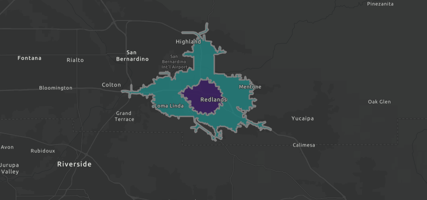

```python
# Plot on a map
buffer_map2 = gis.map('Redlands, CA')
buffer_map2.basemap = 'dark-gray-vector'
buffer_map2
```

```python
drive_time_df.spatial.plot(map_widget=buffer_map2,
                   renderer_type='c',  # for class breaks renderer
                   method='esriClassifyNaturalBreaks',  # classification algorithm
                   class_count=3,  # choose the number of classes
                   col='bufferRadii',  # numeric column to classify
                   cmap='viridis',  # color map to pick colors from for each class
                   alpha=0.7  # specify opacity
                   )
```

```
True
```

### Enriching a named statistical area

In all previous examples of different study area types, locations were defined as either points or polygons. Study area locations can also be passed as one or many named statistical areas. This form of study area lets you define an area as a standard geographic statistical feature, such as a census or postal area, for example, to obtain enrichment information for a U.S. state, county, or ZIP Code or a Canadian province or postal code. We will explore Named statistical areas in detail in the next section.

#### Enriching a zip code

Enriching zip code 92373 in California using the 'Age' data collection:

```python
usa = Country.get('US')
```

```python
redlands = usa.subgeographies.states['California'].zip5['92373']
```

```python
type(redlands)
```

```
arcgis.geoenrichment.enrichment.NamedArea
```

```python
redlands
```

```
<NamedArea name:"Redlands" area_id="92373", level="US.ZIP5", country="United States">
```

```python
redlands_df = enrich(study_areas=[redlands], data_collections=['Age'] )
```

```python
redlands_df
```

|  | ID | OBJECTID | StdGeographyLevel | StdGeographyName | StdGeographyID | sourceCountry | aggregationMethod | populationToPolygonSizeRating | apportionmentConfidence | HasData | ... | FEM45 | FEM50 | FEM55 | FEM60 | FEM65 | FEM70 | FEM75 | FEM80 | FEM85 | SHAPE |
| --- | --- | --- | --- | --- | --- | --- | --- | --- | --- | --- | --- | --- | --- | --- | --- | --- | --- | --- | --- | --- | --- |
| 0 | 0 | 1 | US.ZIP5 | Redlands | 92373 | US | Query:US.ZIP5 | 2.191 | 2.576 | 1 | ... | 1024 | 1089 | 1113 | 1184 | 1101 | 970 | 662 | 475 | 701 | {"rings": [[[-117.13603999963594, 34.032169999... |

1 rows × 47 columns

##### Visualize results on a map

The returned spatial dataframe can be visualized on a map as shown below:

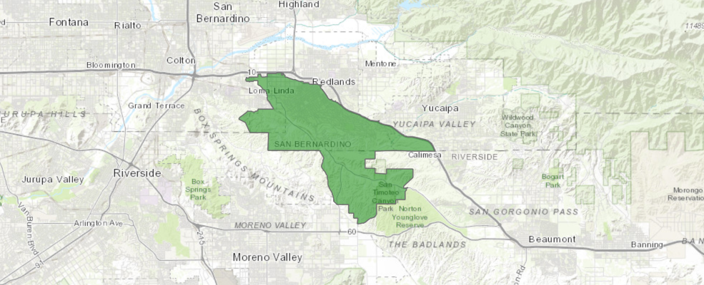

```python
zip_map = gis.map('Redlands, CA')
zip_map
```

```python
redlands_df.spatial.plot(zip_map)
```

```
True
```

#### Enriching all counties in a state

```python
ca_counties = usa.subgeographies.states['California'].counties
```

```python
counties_df = enrich(study_areas=ca_counties, data_collections=['Age'])
counties_df.head()
```

|  | ID | OBJECTID | StdGeographyLevel | StdGeographyName | StdGeographyID | sourceCountry | aggregationMethod | populationToPolygonSizeRating | apportionmentConfidence | HasData | ... | FEM45 | FEM50 | FEM55 | FEM60 | FEM65 | FEM70 | FEM75 | FEM80 | FEM85 | SHAPE |
| --- | --- | --- | --- | --- | --- | --- | --- | --- | --- | --- | --- | --- | --- | --- | --- | --- | --- | --- | --- | --- | --- |
| 0 | 0 | 1 | US.Counties | Alameda County | 06001 | US | Query:US.Counties | 2.191 | 2.576 | 1 | ... | 55457 | 54029 | 55299 | 50442 | 42912 | 34127 | 22548 | 15100 | 18391 | {"rings": [[[-122.2716789998329, 37.9047240001... |
| 1 | 1 | 2 | US.Counties | Alpine County | 06003 | US | Query:US.Counties | 2.191 | 2.576 | 1 | ... | 38 | 42 | 62 | 39 | 55 | 30 | 12 | 10 | 5 | {"rings": [[[-119.90059599883206, 38.930759999... |
| 2 | 2 | 3 | US.Counties | Amador County | 06005 | US | Query:US.Counties | 2.191 | 2.576 | 1 | ... | 1011 | 1162 | 1591 | 1813 | 1739 | 1527 | 968 | 667 | 733 | {"rings": [[[-120.07763899965389, 38.708886999... |
| 3 | 3 | 4 | US.Counties | Butte County | 06007 | US | Query:US.Counties | 2.191 | 2.576 | 1 | ... | 5383 | 5817 | 6860 | 7023 | 6568 | 5293 | 3614 | 2437 | 3396 | {"rings": [[[-121.4046210002662, 40.1466409995... |
| 4 | 4 | 5 | US.Counties | Calaveras County | 06009 | US | Query:US.Counties | 2.191 | 2.576 | 1 | ... | 1352 | 1649 | 2219 | 2371 | 2307 | 1942 | 1206 | 727 | 688 | {"rings": [[[-120.07246000003855, 38.509156000... |

5 rows × 47 columns

##### Visualize results on a map

[figure not shown]

```python
county_map = gis.map('California')
county_map
```

```python
counties_df.spatial.plot(map_widget=county_map,
               renderer_type='c',  # for class breaks renderer
               method='esriClassifyNaturalBreaks',  # classification algorithm
               class_count=5,  # choose the number of classes
               col='FEM75',  # numeric column to classify
               cmap='viridis',  # color map to pick colors from for each class
               alpha=0.7  # specify opacity
               )
```

```
True
```

```python
county_map.legend=True
```

#### Using comparison levels

Using `comparison_levels` the information for the study areas can also be compared with standard geography areas in other levels. For example, if the study area is a zip code, you can compare enriched information for this zip code with information for the county or the state.

**Example 1**

Let's look at an example of enriching a zip code (study area) and then comparing its enrichment information with information for the county to which the zip code belongs using `comparison_levels`.

```python
fontana = usa.subgeographies.states['California'].zip5['92336']
```

```python
testdf1 = enrich(study_areas=[fontana], data_collections=['Age'],
                 comparison_levels=['US.Counties'])
```

```python
testdf1.head()
```

|  | ID | OBJECTID | StdGeographyLevel | StdGeographyName | StdGeographyID | sourceCountry | aggregationMethod | populationToPolygonSizeRating | apportionmentConfidence | HasData | ... | FEM45 | FEM50 | FEM55 | FEM60 | FEM65 | FEM70 | FEM75 | FEM80 | FEM85 | SHAPE |
| --- | --- | --- | --- | --- | --- | --- | --- | --- | --- | --- | --- | --- | --- | --- | --- | --- | --- | --- | --- | --- | --- |
| 0 | 0 | 1 | US.ZIP5 | Fontana | 92336 | US | Query:US.ZIP5 | 2.191 | 2.576 | 1 | ... | 3458 | 3134 | 2975 | 2353 | 1777 | 1176 | 706 | 389 | 366 | {"rings": [[[-117.42984999972606, 34.187269999... |
| 1 | 0 | 2 | US.Counties | San Bernardino County | 06071 | US | Query:US.Counties | 2.191 | 2.576 | 1 | ... | 65463 | 64654 | 66066 | 60308 | 49629 | 36487 | 23911 | 15572 | 16245 | None |

2 rows × 47 columns

The first row in the table above shows data for the requested zip and the second row has the data it was compared against - `US.counties`. We can see how using County as the `comparison_level`, we are able to compare the enriched study area (zip code) with information for the county it was compared to.

**Example 2**

Let's look at another example. In this example below, the 92373 zip code in Redlands intersects with both Riverside and San Bernardino counties in California. Hence, when using `comparsion_levels` both these counties are returned along with the results for the named zip code. We can also add State to the list of `comparsion_levels` to output results for counties and well as states.

```python
redlands = usa.subgeographies.states['California'].zip5['92373']
```

```python
testdf2 = enrich(study_areas=[redlands], data_collections=['Age'],
       comparison_levels=['US.Counties', 'US.States'])
```

```python
testdf2.columns
```

```
Index(['ID', 'OBJECTID', 'StdGeographyLevel', 'StdGeographyName',
       'StdGeographyID', 'sourceCountry', 'aggregationMethod',
       'populationToPolygonSizeRating', 'apportionmentConfidence', 'HasData',
       'MALE0', 'MALE5', 'MALE10', 'MALE15', 'MALE20', 'MALE25', 'MALE30',
       'MALE35', 'MALE40', 'MALE45', 'MALE50', 'MALE55', 'MALE60', 'MALE65',
       'MALE70', 'MALE75', 'MALE80', 'MALE85', 'FEM0', 'FEM5', 'FEM10',
       'FEM15', 'FEM20', 'FEM25', 'FEM30', 'FEM35', 'FEM40', 'FEM45', 'FEM50',
       'FEM55', 'FEM60', 'FEM65', 'FEM70', 'FEM75', 'FEM80', 'FEM85', 'SHAPE'],
      dtype='object')
```

```python
testdf2.head()
```

|  | ID | OBJECTID | StdGeographyLevel | StdGeographyName | StdGeographyID | sourceCountry | aggregationMethod | populationToPolygonSizeRating | apportionmentConfidence | HasData | ... | FEM45 | FEM50 | FEM55 | FEM60 | FEM65 | FEM70 | FEM75 | FEM80 | FEM85 | SHAPE |
| --- | --- | --- | --- | --- | --- | --- | --- | --- | --- | --- | --- | --- | --- | --- | --- | --- | --- | --- | --- | --- | --- |
| 0 | 0 | 1 | US.ZIP5 | Redlands | 92373 | US | Query:US.ZIP5 | 2.191 | 2.576 | 1 | ... | 1024 | 1089 | 1113 | 1184 | 1101 | 970 | 662 | 475 | 701 | {"rings": [[[-117.13603999963594, 34.032169999... |
| 1 | 0 | 2 | US.Counties | Riverside County | 06065 | US | Query:US.Counties | 2.191 | 2.576 | 1 | ... | 71840 | 71254 | 73314 | 68647 | 60386 | 49449 | 35062 | 23797 | 25463 | None |
| 2 | 0 | 3 | US.Counties | San Bernardino County | 06071 | US | Query:US.Counties | 2.191 | 2.576 | 1 | ... | 65463 | 64654 | 66066 | 60308 | 49629 | 36487 | 23911 | 15572 | 16245 | None |
| 3 | 0 | 4 | US.States | California | 06 | US | Query:US.States | 2.191 | 2.576 | 1 | ... | 1222805 | 1227409 | 1264110 | 1182621 | 1012441 | 803457 | 549654 | 374499 | 447146 | None |

4 rows × 47 columns

```python
testdf2.iloc[:, -20:]
```

|  | MALE85 | FEM0 | FEM5 | FEM10 | FEM15 | FEM20 | FEM25 | FEM30 | FEM35 | FEM40 | FEM45 | FEM50 | FEM55 | FEM60 | FEM65 | FEM70 | FEM75 | FEM80 | FEM85 | SHAPE |
| --- | --- | --- | --- | --- | --- | --- | --- | --- | --- | --- | --- | --- | --- | --- | --- | --- | --- | --- | --- | --- |
| 0 | 380 | 877 | 859 | 940 | 902 | 1187 | 1190 | 1150 | 1273 | 1041 | 1024 | 1089 | 1113 | 1184 | 1101 | 970 | 662 | 475 | 701 | {"rings": [[[-117.13603999963594, 34.032169999... |
| 1 | 17664 | 85123 | 86025 | 83957 | 80112 | 80542 | 98617 | 91315 | 79758 | 71974 | 71840 | 71254 | 73314 | 68647 | 60386 | 49449 | 35062 | 23797 | 25463 | None |
| 2 | 9848 | 79131 | 78595 | 76288 | 71381 | 78383 | 95432 | 87077 | 73658 | 65402 | 65463 | 64654 | 66066 | 60308 | 49629 | 36487 | 23911 | 15572 | 16245 | None |
| 3 | 274381 | 1221927 | 1234947 | 1248664 | 1240920 | 1337702 | 1543578 | 1464688 | 1349773 | 1210247 | 1222805 | 1227409 | 1264110 | 1182621 | 1012441 | 803457 | 549654 | 374499 | 447146 | None |

To understand how the data is different between the zip code, the two counties and the state, let's plot the male to female ratio for ages 80-85.

```python
# Create a dataframe with new Male_Female_Ratio column
bar_df = testdf2.loc[:,['StdGeographyName','FEM80','MALE80']]
bar_df['Male_Female_Ratio'] = bar_df['MALE80'] / bar_df['FEM80']
bar_df
```

|  | StdGeographyName | FEM80 | MALE80 | Male_Female_Ratio |
| --- | --- | --- | --- | --- |
| 0 | Redlands | 475 | 345 | 0.726316 |
| 1 | Riverside County | 23797 | 19288 | 0.810522 |
| 2 | San Bernardino County | 15572 | 11698 | 0.751220 |
| 3 | California | 374499 | 283158 | 0.756098 |

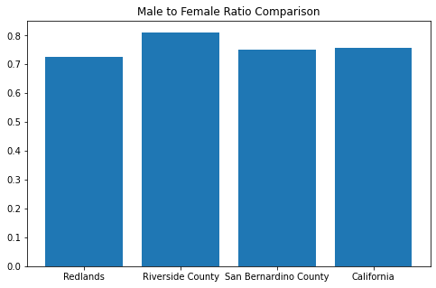

```python
# Plot the Male_Female_Ratio
import matplotlib.pyplot as plt
%matplotlib inline
plt.figure(figsize = (8,5))
plt.bar(x = 'StdGeographyName', height = 'Male_Female_Ratio', data = bar_df)
plt.title('Male to Female Ratio Comparison');
```

From the above plot, we can see minor difference in the male/female ratio between two counties, the state and Redlands (Zip=92373).

### Enriching Arbitrary Geometries

Enrichment not only works on clearly defined geometries such as county or state boundaries but it can also power arbitrary goemetires (random polygon on a map or an area covering parts of different counties etc.) just as well. Let's look at an example of how an arbitrary geometry can be `enrich()`ed.

In this example, we will:

1. Draw a map of Los Angeles, CA
2. Ask the user to draw a polygon on the map
3. Enrich the polygon drawn by the user
4. Visualize enriched geometry on a map

#### Create a Map

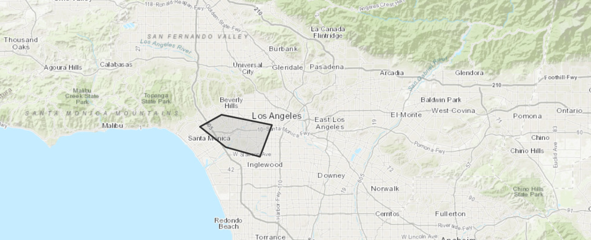

```python
la_map = gis.map('Los Angeles, CA')
la_map
```

#### Enable User Input

Here, we will define a callback function that enables user input. If no input is provided, a default polygon geometry will be enriched.

```python
# Define the callback function.
drawn_polygon = None
def draw_poly(la_map, g):
    global drawn_polygon
    drawn_polygon = g

# Set draw_poly as the callback function to be invoked when a polygon is drawn on the map
drawn_polygon = la_map.on_draw_end(draw_poly)
```

Now, run the cell below and then draw a polygon on `la_map`, finish drawing by double clicking the mouse pointer. If no map is drawn within 30 seconds, a default polygon geometry will be used for enrichment.

```python
import time
# Draw polygon
la_map.draw("polygon")

# Sleep for 30 seconds
time.sleep(30)

# Use this as default polygon if no polygon drawn on map
drawn_polygon = {'spatialReference': {'latestWkid': 3857, 'wkid': 102100},
 'rings': [[[-13176442.352731517, 4035051.715228523],
   [-13167152.267973447, 4032788.462594141],
   [-13169738.58648519, 4023675.1384639805],
   [-13178995.82720767, 4028428.5661604665],
   [-13176442.352731517, 4035051.715228523]]]}
```

```python
# Check drawn polygon
drawn_polygon
```

[output not shown]

#### Enrich Drawn Geometry

```python
from arcgis.geometry import Polygon
poly = Polygon(drawn_polygon)
```

```python
enriched_line_df2 = enrich(study_areas=[poly],
       analysis_variables=["Age.FEM45","Age.FEM55","Age.FEM65"])

enriched_line_df2
```

|  | ID | OBJECTID | sourceCountry | aggregationMethod | populationToPolygonSizeRating | apportionmentConfidence | HasData | FEM45 | FEM55 | FEM65 | SHAPE |
| --- | --- | --- | --- | --- | --- | --- | --- | --- | --- | --- | --- |
| 0 | 0 | 1 | US | BlockApportionment:US.BlockGroups | 2.191 | 2.576 | 1 | 11964 | 12174 | 9685 | {"rings": [[[-118.41408756542211, 34.064264163... |

#### Visualize Enriched Geometry

[figure not shown]

```python
# Plot on a map
poly_map2 = gis.map('Los Angeles, CA')
poly_map2
```

We can clearly see the enriched geometry on this map. Clicking on the geometry will display enriched features.

```python
# Plot enriched area around line
enriched_line_df2.spatial.plot(poly_map2)
```

```
True
```

## Conclusion

In this part of the `arcgis.geoenrichment` module guide series, you were introduced to the concept of study areas and how Geoenrichment uses a study area to define the location of the point, polyline or area that you want to enrich. You have also seen in detail how different types of study areas can be enriched and visualized on a map.

In the subsequent pages, you will learn about:

1. Exploring Named Statistical Areas (explains where to enrich continued)
2. Data Collections and GeoEnrichment coverage (explains what datasets/variables to enrich with)
3. Generating Reports
4. Standard Geography Queries